# First Assignment

Data

06/05/2023

# Please complete all the tasks listed below. After completing the tasks download the .Rmd file and upload in the peer review item for grading.

# Additionally please write text between the code chunks explaining what each code chunk is about.

1.a bulleted list with sub-bullets under at least one item (10 pt)

- Item 1
  - Subitem 1.1
  - Subitem 1.2
- Item 2
  - Subitem 2.1
  - Subitem 2.2

2.a numbered list (10 pt)

1. Item 1
2. Item 2
3. Item 3
4. Item 4

3.some words italicized (5 pt)

*This is my italized text*

4.some words in bold print (5 pt)

**This is my bold text**

5.two levels of headers (10 pt)

# This is my header 1

## This is my header 2

6.the results of some R code without showing the code (10 pt)

```
## [1] "This is my results without showing thw code"
```

7.a table of text at least 3 columns wide and 3 rows long (10 pt)

| header 1 | header 2 | header 3 |
| --- | --- | --- |
| element | element | element |
| element | element | element |
| element | element | element |

8.a plot (show the code that generates the plot) (10 pt)

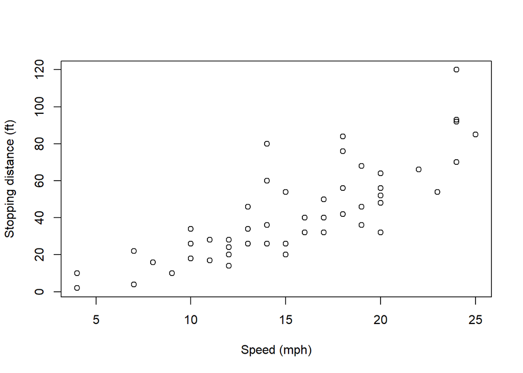

```r
library(datasets)
data(cars)

plot(cars, xlab = "Speed (mph)", ylab = "Stopping distance (ft)")
```

10.Execution of .Rmd file (10 pt)

11.Upload and execution of knitted pdf (10 pt)